# Assignment #3

```r
library(tidyverse)         # for graphing and data cleaning
library(tidymodels)        # for modeling
library(themis)            # for step functions for unbalanced data
library(doParallel)        # for parallel processing
library(stacks)            # for stacking models
library(naniar)            # for examining missing values (NAs)
library(lubridate)         # for date manipulation
library(moderndive)        # for King County housing data
library(vip)               # for variable importance plots
library(patchwork)         # for combining plots nicely
theme_set(theme_minimal()) # Lisa's favorite theme
```

```r
data("lending_club")
# Data dictionary (as close as I could find): https://www.kaggle.com/wordsforthewise/lending-club/discussion/170691
```

When you finish the assignment, remove the `#` from the options chunk at the top, so that messages and warnings aren’t printed. If you are getting errors in your code, add `error = TRUE` so that the file knits. I would recommend not removing the `#` until you are completely finished.

## Put it on GitHub!

From now on, GitHub should be part of your routine when doing assignments. I recommend making it part of your process anytime you are working in R, but I’ll make you show it’s part of your process for assignments.

**Task**: When you are finished with the assignment, post a link below to the GitHub repo for the assignment. Make sure the link goes to a spot in the repo where I can easily find this assignment. For example, if you have a website with a blog and post the assignment as a blog post, link to the post’s folder in the repo. As an example, I’ve linked to my GitHub stacking material [here](https://github.com/llendway/ads_website/tree/master/_posts/2021-03-22-stacking).

[Github Link](https://github.com/miarothberg/assignmnet_03_093021)

## Modeling

We’ll be using the `lending_club` dataset from the `modeldata` library, which is part of `tidymodels`. The data dictionary they reference doesn’t seem to exist anymore, but it seems the one on this [kaggle discussion](https://www.kaggle.com/wordsforthewise/lending-club/discussion/170691) is pretty close. It might also help to read a bit about [Lending Club](https://en.wikipedia.org/wiki/LendingClub) before starting in on the exercises.

The outcome we are interested in predicting is `Class`. And according to the dataset’s help page, its values are “either ‘good’ (meaning that the loan was fully paid back or currently on-time) or ‘bad’ (charged off, defaulted, or 21-120 days late)”.

**Tasks:**

1. Explore the data, concentrating on examining distributions of variables and examining missing values.

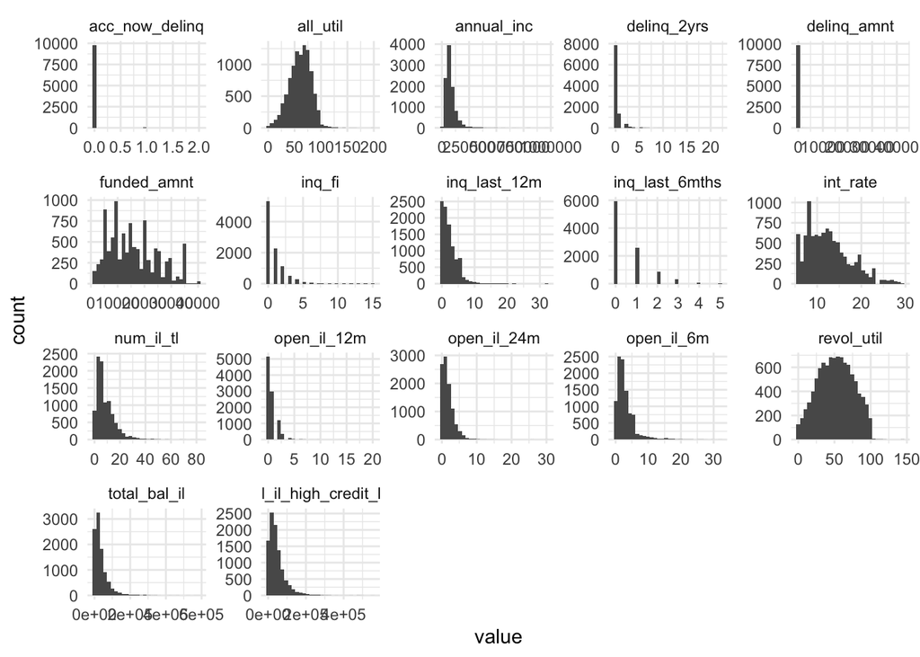

```r
lending_club %>%
  select(where(is.numeric)) %>%
  pivot_longer(cols = everything(),
               names_to = "variable",
               values_to = "value") %>%
  ggplot(aes(x = value)) +
  geom_histogram(bins = 30) +
  facet_wrap(vars(variable),
             scales = "free")
```

> Many of the quantitative variables appear to be right skewed, especially the `open_il_xm` variables which represent the number of installment accounts opened in the past x months. The `revol_util` variable in particular has a very normal distribution (Revolving line utilization rate, or the amount of credit the borrower is using relative to all available revolving credit.)

```r
lending_club %>%
  add_n_miss() %>%
  count(n_miss_all)
```

| n_miss_all | n |
| --- | --- |
| 0 | 9857 |

> It appears that there are no missing values in this dataset
2. Split the data into training and test, putting 75% in the training data. Stratify by `Class` (add `strata =`Class`to the`initial_split()` function).

```r
set.seed(494) # for reproducibility

# remove the #'s once you've defined these - this is so we all have the same name
lending_split <- initial_split(lending_club,
                             prop = .75, strata = Class)

lending_training <- training(lending_split)
lending_test <- testing(lending_split)
```

3. Set up the recipe and the pre-processing steps to build a lasso model. Some steps you should take:
- Use `step_upsample()` from the `themis` library to upsample the “bad” category so that it is 50% of the “good” category. Do this by setting `over_ratio = .5`.
- Use `step_downsample()` from the `themis` library to downsample the “good” category so the bads and goods are even - set `under_ratio = 1`. Make sure to do this step AFTER `step_upsample()`.
- Make all integer variables numeric (I’d highly recommend using `step_mutate_at()` and using the `all_numeric()` helper or this will be a lot of code). This step might seem really weird right now, but we’ll want to do this for the model interpretation we’ll do in a later assignment.
- Think about grouping factor variables with many levels.
- Make categorical variables dummy variables (make sure NOT to do this to the outcome variable).
- Normalize quantitative variables.

Once you have that, use `prep()`, `juice()`, and `count()` to count the number of observations in each class. They should be equal. This dataset will be used in building the model, but the data without up and down sampling will be used in evaluation.

```r
set.seed(456)

lasso_recipe <- recipe(Class ~.,
                       data = lending_training) %>%

  #use step_upsample to upsample bad category
  step_upsample(Class, over_ratio = 0.5) %>%

  #use step_downsample to downsample good category
  step_downsample(Class, under_ratio = 1) %>%

  #make all integer variables numbric
  step_mutate_at(all_numeric(), fn = ~as.numeric(.)) %>% # is this right? probably not.

  #think about grouping factor variables with many levels
  #group into northeseat/midwest etc
  step_mutate(addr_state = as.character(addr_state),
              addr_state = case_when(
                addr_state %in% c("WA", "OR", "CA", "ID", "MT", "WY", "NV", "UT", "CO", "AZ", "NM") ~ "West",
                addr_state %in% c("ND", "SD", "NE", "KS", "OK", "TX", "LA", "AR", "MO", "IA", "MN", "WI", "MI", "IL", "IN", "OH") ~ "Midwest",
                addr_state %in% c("MD", "DE", "DC", "VA", "WV", "KY", "TN", "NC", "MS", "AL", "GA", "SC", "FL") ~ "South",
                addr_state %in% c("PA", "NJ", "NY", "RI", "CT", "MA", "VT", "NH", "ME") ~ "North",
                TRUE ~ addr_state),
              addr_state = as.factor(addr_state),
              sub_grade = as.character(sub_grade),
              sub_grade = case_when(
                "A" %in% sub_grade ~ "A",
                "B" %in% sub_grade ~ "B",
                "C" %in% sub_grade ~ "C",
                "D" %in% sub_grade ~ "D",
                "E" %in% sub_grade ~ "E",
                "F" %in% sub_grade ~ "F",
                "G" %in% sub_grade ~ "G",
                TRUE ~ sub_grade
              ),
              sub_grade = as.factor(sub_grade)
              ) %>%

  #make categorical variables dummys
  step_dummy(all_nominal(),
           -all_outcomes()) %>%

  #normalize quantitative variables
  step_normalize(all_predictors(),
               -all_nominal())
```

Once you have that, use `prep()`, `juice()`, and `count()` to count the number of observations in each class. They should be equal. This dataset will be used in building the model, but the data without up and down sampling will be used in evaluation.

```r
lasso_recipe %>%
  prep(lending_training) %>%
  # using bake(new_data = NULL) gives same result as juice()
  # bake(new_data = NULL)
  juice() %>%
  count(Class)
```

| Class | n |
| --- | --- |
| bad | 3504 |
| good | 3504 |

4. Set up the lasso model and workflow. We will tune the `penalty` parameter.

```r
lasso_mod <-
  # Define a lasso model
  logistic_reg(mixture = 1) %>%
  # Set the engine to "glmnet"
  set_engine("glmnet") %>%
  # The parameters we will tune.
  set_args(penalty = tune()) %>%
  # Use "regression"
  set_mode("classification")

lasso_wf <-
  # Set up the workflow
  workflow() %>%
  # Add the recipe
  add_recipe(lasso_recipe) %>%
  # Add the modeling
  add_model(lasso_mod)
```

5. Set up the model tuning for the `penalty` parameter. Be sure to add the `control_stack_grid()` for the `control` argument so we can use these results later when we stack. Find the accuracy and area under the roc curve for the model with the best tuning parameter. Use 5-fold cv.

Tune:

```r
set.seed(494) #for reproducible 5-fold
lending_cv <- vfold_cv(lending_training, v = 5)

penalty_grid <- grid_regular(penalty(),
                             levels = 20)

ctrl_grid <- control_stack_grid()

# tune the model
lasso_tune <- lasso_wf %>%
  tune_grid(
    resamples = lending_cv,
    grid = penalty_grid,
    control = ctrl_grid
    )
```

```r
lasso_tune %>%
  show_best(metric = "roc_auc")
```

| penalty | .metric | .estimator | mean | n | std_err | .config |
| --- | --- | --- | --- | --- | --- | --- |
| 0.0263665090 | roc_auc | binary | 0.7387590 | 5 | 0.005861166 | Preprocessor1_Model17 |
| 0.0885866790 | roc_auc | binary | 0.7347342 | 5 | 0.007140165 | Preprocessor1_Model18 |
| 0.0078475997 | roc_auc | binary | 0.7291746 | 5 | 0.007702722 | Preprocessor1_Model16 |
| 0.0023357215 | roc_auc | binary | 0.7156415 | 5 | 0.009578236 | Preprocessor1_Model15 |
| 0.0006951928 | roc_auc | binary | 0.7106408 | 5 | 0.009986894 | Preprocessor1_Model14 |

```r
lasso_tune %>%
  show_best(metric = "accuracy")
```

| penalty | .metric | .estimator | mean | n | std_err | .config |
| --- | --- | --- | --- | --- | --- | --- |
| 0.0885866790 | accuracy | binary | 0.7148220 | 5 | 0.007697989 | Preprocessor1_Model18 |
| 0.0263665090 | accuracy | binary | 0.7115786 | 5 | 0.003772604 | Preprocessor1_Model17 |
| 0.0078475997 | accuracy | binary | 0.6954809 | 5 | 0.006414923 | Preprocessor1_Model16 |
| 0.0023357215 | accuracy | binary | 0.6897967 | 5 | 0.009065138 | Preprocessor1_Model15 |
| 0.0006951928 | accuracy | binary | 0.6880381 | 5 | 0.009680887 | Preprocessor1_Model14 |

> penalty = 0.0263665090 has the highest area under the curve with a mean of 0.7387590. penalty = 0.0885866790 has the highest accuract with a mean of 0.7148220.
6. Set up the recipe and the pre-processing steps to build a random forest model. You shouldn’t have to do as many steps. The only steps you should need to do are making all integers numeric and the up and down sampling.

```r
set.seed(456)
rf_recipe <- recipe(Class ~.,
                       data = lending_training) %>%

  #use step_upsample to upsample bad category
  step_upsample(Class, over_ratio = 0.5) %>%

  #use step_downsample to downsample good category
  step_downsample(Class, under_ratio = 1) %>%

  #make all integer variables numbric
  step_mutate_at(all_numeric(), fn = ~as.numeric(.))
```

7. Set up the random forest model and workflow. We will tune the `mtry` and `min_n` parameters and set the number of trees, `trees`, to 100 (otherwise the next steps take too long).

```r
rf_model <- rand_forest(mtry = tune(),
              min_n = tune(),
              trees = 100) %>%
  set_mode("classification") %>% #could have taken out
  set_engine("ranger")

rf_workflow <- workflow() %>%
  add_recipe(rf_recipe) %>%
  add_model(rf_model)
```

8. Set up the model tuning for both the `mtry` and `min_n` parameters. Be sure to add the `control_stack_grid()` for the `control` argument so we can use these results later when we stack. Use only 3 levels in the grid. For the `mtry` parameter, you need to put `finalize(mtry(), lending_training %>% select(-Class))` in as an argument instead of just `mtry()`, where `lending_training` is the name of your training data. This is because the `mtry()` grid will otherwise have unknowns in it. This part can take a while to run.

```r
penalty_grid1 <- grid_regular(min_n(), finalize(mtry(), lending_training %>% select(-Class)),
                             levels = 3)

rf_tune <- rf_workflow %>%
  tune_grid(
    resamples = lending_cv,
    control = control_stack_grid(),
    grid = penalty_grid1
  )
```

9. Find the best tuning parameters. What are the accuracy and area under the ROC curve for the model with those tuning parameters?

```r
rf_tune %>%
  show_best(metric = "roc_auc")
```

| mtry | min_n | .metric | .estimator | mean | n | std_err | .config |
| --- | --- | --- | --- | --- | --- | --- | --- |
| 1 | 21 | roc_auc | binary | 0.7382745 | 5 | 0.004127273 | Preprocessor1_Model2 |
| 1 | 40 | roc_auc | binary | 0.7338695 | 5 | 0.008461517 | Preprocessor1_Model3 |
| 1 | 2 | roc_auc | binary | 0.7289525 | 5 | 0.005703746 | Preprocessor1_Model1 |
| 11 | 21 | roc_auc | binary | 0.7253148 | 5 | 0.008681840 | Preprocessor1_Model5 |
| 11 | 2 | roc_auc | binary | 0.7191475 | 5 | 0.006956063 | Preprocessor1_Model4 |

```r
rf_tune %>%
  show_best(metric = "accuracy")
```

| mtry | min_n | .metric | .estimator | mean | n | std_err | .config |
| --- | --- | --- | --- | --- | --- | --- | --- |
| 11 | 2 | accuracy | binary | 0.9262728 | 5 | 0.003164891 | Preprocessor1_Model4 |
| 22 | 2 | accuracy | binary | 0.9207267 | 5 | 0.005424711 | Preprocessor1_Model7 |
| 11 | 21 | accuracy | binary | 0.9180211 | 5 | 0.003571819 | Preprocessor1_Model5 |
| 22 | 21 | accuracy | binary | 0.9081450 | 5 | 0.002982463 | Preprocessor1_Model8 |
| 11 | 40 | accuracy | binary | 0.9036798 | 5 | 0.001274509 | Preprocessor1_Model6 |

> The model with mtry =1 and min_n = 21 has the best area under the roc curve with a mean of 0.7382745. The model with mtry = 11 and min_n = 2 has the best accuracy with a mean of 0.9262728.

```r
rf_tune %>%
  select(id, .metrics) %>%
  unnest(.metrics)
```

[output not shown]

10. Next, we will fit a boosted tree using xgboost. We will only tune the `learn_rate` parameter. I have specified the model, recipe, and workflow below already (uncomment the code - you can this by highlighting it and then in the code tab at the top, choose comment/uncomment lines). You need to set up a grid of ten values for the tuning parameter and tune the model. Be sure to add the `control_stack_grid()` for the `control` argument so we can use these results later when we stack.

```r
xgboost_spec <-
  boost_tree(
    trees = 1000,
    min_n = 5,
    tree_depth = 2,
    learn_rate = tune(),
    loss_reduction = 10^-5,
    sample_size = 1) %>%
  set_mode("classification") %>%
  set_engine("xgboost")

xgboost_recipe <- recipe(formula = Class ~ ., data = lending_training) %>%
  step_upsample(Class, over_ratio = .5) %>%
  step_downsample(Class, under_ratio = 1) %>%
  step_mutate_at(all_numeric(),
                 fn = ~as.numeric(.)) %>%
  step_novel(all_nominal_predictors()) %>%
  step_dummy(all_nominal_predictors(), one_hot = TRUE) %>%
  step_zv(all_predictors())

xgboost_workflow <-
  workflow() %>%
  add_recipe(xgboost_recipe) %>%
  add_model(xgboost_spec)

set.seed(494)
registerDoParallel()

boost_grid <- grid_regular(learn_rate(),
                           levels = 10)


boost_tune <- tune_grid(
  xgboost_workflow,
  #val_split,
  grid = boost_grid,
  control = control_stack_grid(),
  resamples = lending_cv
)
```

11. Find the best tuning parameters. What are the accuracy and area under the ROC curve for the model with those tuning parameters?

```r
boost_tune %>%
  show_best(metric = "roc_auc")
```

| learn_rate | .metric | .estimator | mean | n | std_err | .config |
| --- | --- | --- | --- | --- | --- | --- |
| 1e-03 | roc_auc | binary | 0.7391858 | 5 | 0.007935681 | Preprocessor1_Model08 |
| 1e-02 | roc_auc | binary | 0.7354972 | 5 | 0.006760394 | Preprocessor1_Model09 |
| 1e-04 | roc_auc | binary | 0.7181530 | 5 | 0.007690596 | Preprocessor1_Model07 |
| 1e-09 | roc_auc | binary | 0.7093909 | 5 | 0.008515610 | Preprocessor1_Model02 |
| 1e-08 | roc_auc | binary | 0.7093909 | 5 | 0.008515610 | Preprocessor1_Model03 |

```r
boost_tune %>%
  show_best(metric = "accuracy")
```

| learn_rate | .metric | .estimator | mean | n | std_err | .config |
| --- | --- | --- | --- | --- | --- | --- |
| 1e-01 | accuracy | binary | 0.8070887 | 5 | 0.004291607 | Preprocessor1_Model10 |
| 1e-02 | accuracy | binary | 0.7096826 | 5 | 0.006835859 | Preprocessor1_Model09 |
| 1e-03 | accuracy | binary | 0.6735628 | 5 | 0.014090769 | Preprocessor1_Model08 |
| 1e-08 | accuracy | binary | 0.6721956 | 5 | 0.042730882 | Preprocessor1_Model03 |
| 1e-07 | accuracy | binary | 0.6721956 | 5 | 0.042730882 | Preprocessor1_Model04 |

> learn_rate 1e-03 has the highest area under the curve with a mean of 0.7391858. learn_rate 1e-01 has the highest accuracy with a mean of 0.8070887.

```r
collect_metrics(boost_tune)
```

| learn_rate | .metric | .estimator | mean | n | std_err | .config |
| --- | --- | --- | --- | --- | --- | --- |
| 1e-10 | accuracy | binary | 0.05181206 | 5 | 0.002765385 | Preprocessor1_Model01 |
| 1e-10 | roc_auc | binary | 0.50955214 | 5 | 0.009552144 | Preprocessor1_Model01 |
| 1e-09 | accuracy | binary | 0.65069457 | 5 | 0.036076400 | Preprocessor1_Model02 |
| 1e-09 | roc_auc | binary | 0.70939088 | 5 | 0.008515610 | Preprocessor1_Model02 |
| 1e-08 | accuracy | binary | 0.67219558 | 5 | 0.042730882 | Preprocessor1_Model03 |
| 1e-08 | roc_auc | binary | 0.70939088 | 5 | 0.008515610 | Preprocessor1_Model03 |
| 1e-07 | accuracy | binary | 0.67219558 | 5 | 0.042730882 | Preprocessor1_Model04 |
| 1e-07 | roc_auc | binary | 0.70939088 | 5 | 0.008515610 | Preprocessor1_Model04 |
| 1e-06 | accuracy | binary | 0.67219558 | 5 | 0.042730882 | Preprocessor1_Model05 |
| 1e-06 | roc_auc | binary | 0.70939088 | 5 | 0.008515610 | Preprocessor1_Model05 |

[output cut: 10 more lines]

```r
best_lr <- select_best(boost_tune, "accuracy")
best_lr
```

| learn_rate | .config |
| --- | --- |
| 0.1 | Preprocessor1_Model10 |

12. Create a model stack with the candidate models from the previous parts of the exercise and use the `blend_predictions()` function to find the coefficients of the stacked model. Create a plot examining the performance metrics for the different penalty parameters to assure you have captured the best one. If not, adjust the penalty. (HINT: use the `autoplot()` function). Which models are contributing most?

```r
lending_stack <- stacks() %>%
  add_candidates(lasso_tune) %>%
  add_candidates(rf_tune) %>%
  add_candidates(boost_tune)
```

```r
lending_blend <-
  lending_stack %>%
  blend_predictions()

lending_blend
```

```
## # A tibble: 5 × 3
##   member                     type           weight
##   <chr>                      <chr>           <dbl>
## 1 .pred_good_lasso_tune_1_17 logistic_reg 2.16
## 2 .pred_good_rf_tune_1_2     rand_forest  1.98
## 3 .pred_good_lasso_tune_1_18 logistic_reg 0.588
## 4 .pred_good_boost_tune_1_09 boost_tree   0.159
## 5 .pred_good_rf_tune_1_5     rand_forest  0.000209
```

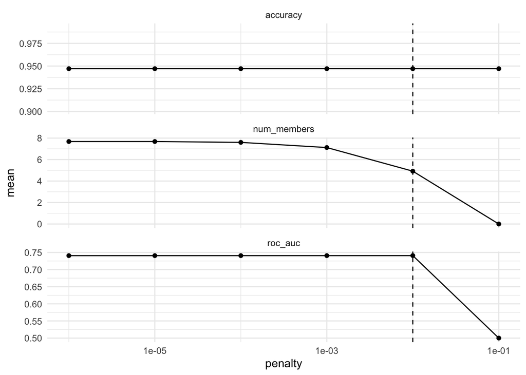

```r
autoplot(lending_blend)
```

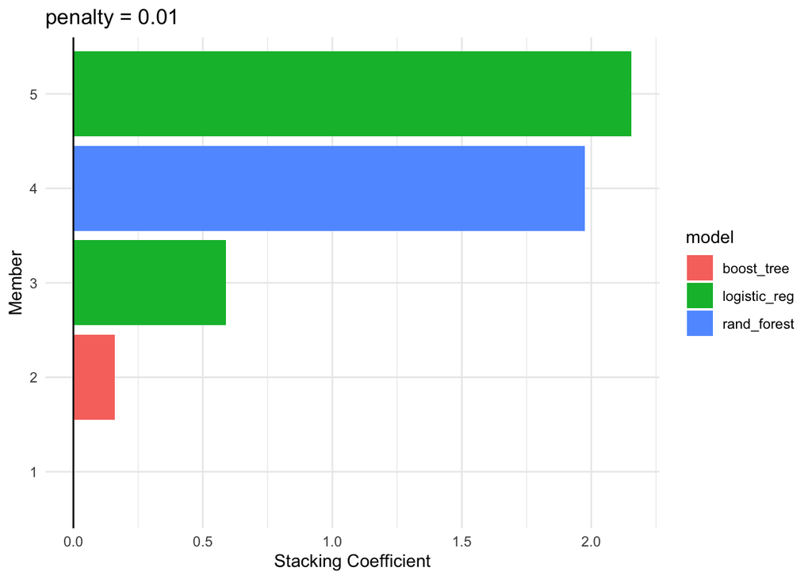

```r
autoplot(lending_blend, type = "weights")
```

> The LASSO (logistic_reg) model is contributing the most, followed by the random forest model.
13. Fit the final stacked model using `fit_members()`. Apply the model to the training data. Compute the accuracy, construct a confusion matrix, and create a density plot with `.pred_good` on the x-axis (the probability of a response of “good”), filled by `Class`. Comment on what you see. *(see below graph) for comments*

```r
lending_final_stack <-
  lending_blend %>%
  fit_members()

lending_final_stack
```

```
## # A tibble: 5 × 3
##   member                     type           weight
##   <chr>                      <chr>           <dbl>
## 1 .pred_good_lasso_tune_1_17 logistic_reg 2.16
## 2 .pred_good_rf_tune_1_2     rand_forest  1.98
## 3 .pred_good_lasso_tune_1_18 logistic_reg 0.588
## 4 .pred_good_boost_tune_1_09 boost_tree   0.159
## 5 .pred_good_rf_tune_1_5     rand_forest  0.000209
```

```r
lending_training_preds <-
  lending_training %>%
  bind_cols(predict(lending_final_stack, .))
```

Compute the accuracy, construct a confusion matrix, and create a density plot with `.pred_good` on the x-axis (the probability of a response of “good”), filled by `Class`. Comment on what you see.

```r
lending_training_preds %>%
  accuracy(truth = Class, estimate = .pred_class)
```

| .metric | .estimator | .estimate |
| --- | --- | --- |
| accuracy | binary | 0.9481872 |

```r
lending_training_preds %>%
  conf_mat(truth = Class, estimate = .pred_class)
```

```
##           Truth
## Prediction  bad good
##       bad     0    0
##       good  383 7009
```

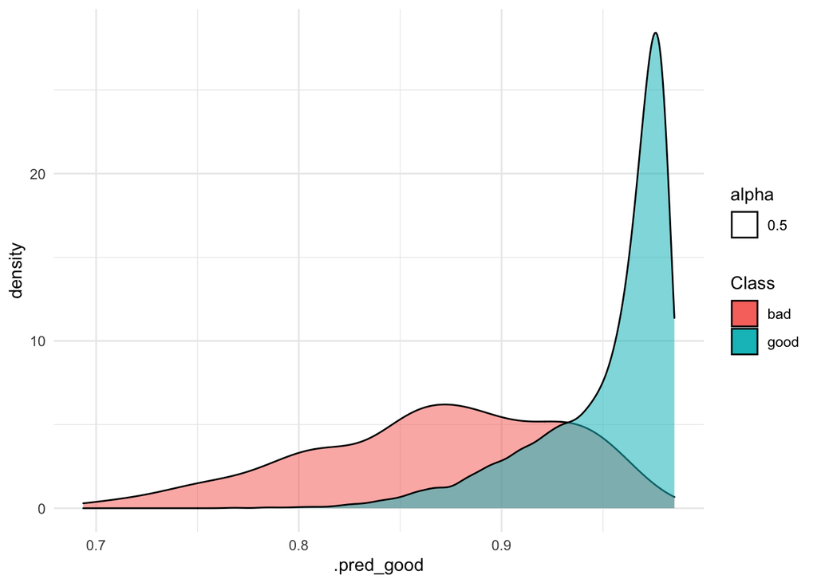

```r
lending_final_stack %>%
  predict(new_data = lending_training, type = "prob") %>%
  bind_cols(lending_training) %>%
  ggplot(aes(x = .pred_good, fill = Class, alpha = 0.5)) +
  geom_density()
```

14. In the previous problem, you saw that although the accuracy was quite high, the true negative rate (aka sensitivity) was terrible. It’s common to see this when one of the classes has low representation. What we want to do now is investigate what happens in each of our models. Below I’ve provided code to investigate the lasso model (where `lasso_tune` is the name of my tuning step). Do similar things for the random forest and xgboost models. If you’d like to have a better true negative rate, which models would you choose and how would you go about doing this in a less manual way (you don’t need to write code to do it - just describe it in words). Be sure to remove the `eval=FALSE` when you are finished.

```r
lasso_tune %>%
  collect_predictions() %>%
  group_by(id, penalty) %>%
  summarize(accuracy = sum((Class == .pred_class))/n(),
            true_neg_rate = sum(Class == "bad" & .pred_class == "bad")/sum(Class == "bad"),
            true_pos_rate = sum(Class == "good" & .pred_class == "good")/sum(Class == "good")) %>%
  group_by(penalty) %>%
  summarize(across(accuracy:true_pos_rate, mean))
```

| penalty | accuracy | true_neg_rate | true_pos_rate |
| --- | --- | --- | --- |
| 1.000000e-10 | 0.6873626 | 0.6227045 | 0.6910633 |
| 3.359818e-10 | 0.6873626 | 0.6227045 | 0.6910633 |
| 1.128838e-09 | 0.6873626 | 0.6227045 | 0.6910633 |
| 3.792690e-09 | 0.6873626 | 0.6227045 | 0.6910633 |
| 1.274275e-08 | 0.6873626 | 0.6227045 | 0.6910633 |
| 4.281332e-08 | 0.6873626 | 0.6227045 | 0.6910633 |
| 1.438450e-07 | 0.6873626 | 0.6227045 | 0.6910633 |
| 4.832930e-07 | 0.6873626 | 0.6227045 | 0.6910633 |
| 1.623777e-06 | 0.6873626 | 0.6227045 | 0.6910633 |
| 5.455595e-06 | 0.6873626 | 0.6227045 | 0.6910633 |

[output cut: 10 more lines]

```r
rf_tune %>%
  collect_predictions() %>%
  group_by(id, mtry, min_n) %>%
  summarize(accuracy = sum((Class == .pred_class))/n(),
            true_neg_rate = sum(Class == "bad" & .pred_class == "bad")/sum(Class == "bad"),
            true_pos_rate = sum(Class == "good" & .pred_class == "good")/sum(Class == "good")) %>%
  group_by(mtry, min_n) %>%
  summarize(across(accuracy:true_pos_rate, mean))
```

| mtry | min_n | accuracy | true_neg_rate | true_pos_rate |
| --- | --- | --- | --- | --- |
| 1 | 2 | 0.8797368 | 0.24841796 | 0.9144225 |
| 1 | 21 | 0.8486186 | 0.33377423 | 0.8770893 |
| 1 | 40 | 0.8216995 | 0.41634026 | 0.8441256 |
| 11 | 2 | 0.9262728 | 0.09211788 | 0.9720405 |
| 11 | 21 | 0.9180211 | 0.09837444 | 0.9630509 |
| 11 | 40 | 0.9036798 | 0.16127092 | 0.9443956 |
| 22 | 2 | 0.9207267 | 0.09978858 | 0.9657538 |
| 22 | 21 | 0.9081450 | 0.11584561 | 0.9516601 |
| 22 | 40 | 0.8967810 | 0.17669381 | 0.9363878 |

```r
boost_tune %>%
  collect_predictions() %>%
  group_by(id, learn_rate) %>%
  summarize(accuracy = sum((Class == .pred_class))/n(),
            true_neg_rate = sum(Class == "bad" & .pred_class == "bad")/sum(Class == "bad"),
            true_pos_rate = sum(Class == "good" & .pred_class == "good")/sum(Class == "good")) %>%
  group_by(learn_rate) %>%
  summarize(across(accuracy:true_pos_rate, mean))
```

| learn_rate | accuracy | true_neg_rate | true_pos_rate |
| --- | --- | --- | --- |
| 1e-10 | 0.05181206 | 1.0000000 | 0.0000000 |
| 1e-09 | 0.65069457 | 0.6955410 | 0.6487530 |
| 1e-08 | 0.67219558 | 0.6697508 | 0.6729121 |
| 1e-07 | 0.67219558 | 0.6697508 | 0.6729121 |
| 1e-06 | 0.67219558 | 0.6697508 | 0.6729121 |
| 1e-05 | 0.67219558 | 0.6697508 | 0.6729121 |
| 1e-04 | 0.67219558 | 0.6697508 | 0.6729121 |
| 1e-03 | 0.67356276 | 0.6937973 | 0.6726105 |
| 1e-02 | 0.70968260 | 0.6348110 | 0.7140197 |
| 1e-01 | 0.80708869 | 0.3853872 | 0.8302778 |